# Final Assignment

Gabrielle

2022-12-08

## INTRODUCTION

eDNA metabarcoding has the potential to serves as a more widely accessible and effective method through which to survey fish species richness. Traditional methods include nets, visual census, and electrofishing. eDNA has the potential to create better analyses of hard to reach locations, such as polar, open-ocean, and deep sea study sites. Additionally, it creates a far less damaging and less stressful procedure for the fish and surrounding habitat. eDNA targets the widespread particle (DNA) trace of a species, and can assist in the detection of rare species that may elude the common snorkeler or scuba diver attempting to have a fish “in hand” as a testament to its presence in that environment.

This report will investigate the research Question: Does Environmental DNA Metabarcoding estimate the species area relationship (SAR) the same or different than traditional fishing gear?

## METHODS

#### Load in the data + clean it:

- area_ha: The area of the lake surveyed in hectares
- dna_richness: The number of unique fish species detected using eDNA metabarcoding
- trad_richness: The number of unique fish species detected using traditional/conventional fishing approaches.

We will drop the few NA values to allow for the statistical analysis to be completed. Future analysis could use a very small number rather than dropping the zeros, which when logged becomes undefined or “-Inf” as it appears in R.

```r
sar <- read_csv(here("data","SAR_data.csv"))

# use janitor() and clean up the names:
sar <- sar %>% clean_names()

# log transform the data:
sar$area_ha_mod = log(sar$area_ha)

sar$dna_richness_mod = log(sar$dna_richness)

sar$trad_richness_mod = log(sar$trad_richness)

# get rid of -Inf values:
sar[is.na(sar) | sar=="-Inf"] = NA

# drop the NA observations:
sar <- drop_na(sar)
```

```r
#### Scatterplot of the raw data to visually inpect it: species richness as found by eDNA methods

sar_scatter_dna <- ggplot(sar, aes(x = area_ha, y = dna_richness)) +
  geom_point() +
  geom_smooth(method = "lm") +
  labs(x = "Area of lake surveyed (hectares)", y = "# of unique fish detected via eDNA") +
  theme_minimal()
# Scatterplot of the relationship between the area of the lake surveyed (in hectares) and the number of unique fish species detected using eDNA metabarcoding.
```

```r
#### Scatterplot of the raw data to visually inspect it: species richness as found by traditional methods

sar_scatter_trad <- ggplot(sar, aes(x = area_ha, y = trad_richness)) +
  geom_point() +
  geom_smooth(method = "lm") +
  labs(x = "Area of Lake Surveyed (hectares)", y = "# of Unique Fish Detected via Traditional Approaches") +
  theme_minimal()

# Scatterplot of the relationship between the area of the lake surveyed (in hectares) and the number of unique fish species detected using traditional/conventional fishing approaches.
```

```r
#### Re-visualize using the log-transformed data:

sar_scatter_dna_mod <- ggplot(sar, aes(x = area_ha_mod, y = dna_richness_mod)) +
  geom_point() +
  geom_smooth(method = "lm") +
  ylim (-2,6) +
  labs(x = "Logged Area of Lake Surveyed (hectares)", y = "Logged # of Unique Fish Detected via eDNA") +
  theme_minimal()

# Scatterplot of the relationship between the logged area of the lake surveyed (in hectares) and the logged number of unique fish species detected using eDNA metabarcoding
```

```r
sar_scatter_trad_mod <- ggplot(sar, aes(x = area_ha_mod, y = trad_richness_mod)) +
  geom_point() +
  geom_smooth(method = "lm") +
  ylim (-2, 6) +
  labs(x = "Logged Area of Lake Surveyed (hectares)", y = "Logged # of Unique Fish Detected via Traditional Approaches") +
  theme_minimal()

# Scatterplot of the relationship between the logged area of the lake surveyed (in hectares) and the logged number of unique fish species detected using traditional/conventional fishing approaches
```

After inspecting the data in its raw form and the log form, we determined it is necessary to log transform the data in order to visualize it. Additionally, it is necessary to tidy up the data into long form in order to create a new variable “method” that encompasses traditional methods and the eDNA barcoding method in order to carry out statistical analysis on the methods.

### Change the data format

```r
sar_b <- read_csv(here("data","SAR_data.csv"))

# use janitor() and clean up the names
sar_b <- sar_b %>% clean_names()

sar_long <- sar_b %>% pivot_longer(cols = c('dna_richness','trad_richness'),
                                 names_to = 'method',
                                 values_to = 'species_richness')

# log transform the data
sar_long$area_ha_log = log(sar_long$area_ha)

sar_long$species_richness_log = log(sar_long$species_richness)

# make -Inf code as NA
sar_long[is.na(sar_long) | sar_long=="-Inf"] = NA

# get rid of the NAs:
sar_long <- drop_na(sar_long)
```

## Visualize, again: long and logged data

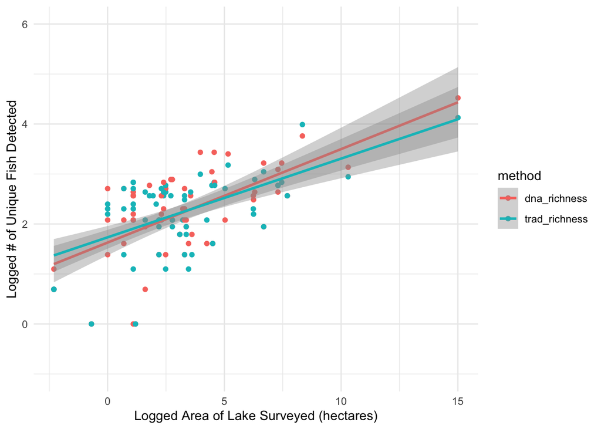

Figure 1. Scatterplot of the relationship between the logged area of the lake surveyed (in hectares) and the logged number of unique fish species detected. Color indicates method used: Peach for eDNA barcoding, Teal for traditional/conventional fishing approaches.

```r
sar_scatter_long_log <- ggplot(sar_long, aes(x = area_ha_log, y = species_richness_log, color = method)) +
  geom_point() +
  geom_smooth(method = "lm") +
  ylim(-1, 6) +
  labs(x = "Logged Area of Lake Surveyed (hectares)", y = "Logged # of Unique Fish Detected") +
  theme_minimal()

sar_scatter_long_log
```

### Suite of Models:

This allows us to investigate whether there is a different effect for the two data collection methods (eDNA barcoding and traditional methods).

Model 0: A simple linear regression. The logged species richness as a function of logged area.

Model 1: A simple linear regression. The logged species richness as a function of the method of data collection.

Model 2: A simple linear regression. The logged species richness as a function of logged area and the method of data collection

Model 3: A simple linear regression. The logged species richness as a function of area interacting with the method of data collection.

```r
m_0 <- lm(species_richness_log ~ area_ha_log, data = sar_long)
summary(m_0)

m_1 <- lm(species_richness_log ~ method, data = sar_long)
summary(m_1)

m_2 <- lm(species_richness_log ~ area_ha_log + method, data = sar_long)
summary(m_2)

m_3 <- lm(species_richness_log ~ area_ha_log * method, data = sar_long)
summary(m_3)
```

[output not shown]

```r
BIC_list <- c(BIC(m_0), BIC(m_1), BIC(m_2), BIC(m_3))


model_output <-rbind(data.frame(glance(m_0)),data.frame(glance(m_1)),data.frame(glance(m_2)),
                     data.frame(glance(m_3))) %>% select(BIC)

model_output <- mutate(model_output, delta.BIC = BIC-min(BIC_list))
model_output$model<-c("Model 0","Model 1","Model 2","Model 3")
model_output<-model_output[,c("model", "BIC", "delta.BIC" )]


kable(model_output, format = "markdown", digits = 3, caption = "BIC, and Delta.BIC for the IDF models. Delta BIC > 7 indicates models that should be dismissed from further consideration.")
```

BIC, and Delta.BIC for the IDF models. Delta BIC > 7 indicates models that should be dismissed from further consideration.

| model | BIC | delta.BIC |
| --- | --- | --- |
| Model 0 | 275.650 | 0.000 |
| Model 1 | 337.547 | 61.897 |
| Model 2 | 280.524 | 4.874 |
| Model 3 | 284.825 | 9.175 |

## RESULTS

The model that performs best is Model 0, a simple linear regression showing logged species richness as a function of logged area.

The delta BIC for Model 1 is 61.897, which is far beyond the BIC < 7 thresh hold, so it is a very unlikely model, and therefore we will dismiss Model 1. This reinforces our understanding that size of study area matters substantially in this research question.

Model 2 and Model 3 are quite similar. Model 2, which is the model performing the second best has a delta BIC = 4.874 (and still under the BIC <7 thresh hold). It is a simple linear regression, logged species richness as a function of logged area and the method of data collection. It would be a model we would want to look into more closely if we were to collect more data. Model 3 is a simple linear regression of the logged species richness as a function of area interacting with the method of data collection. In this model, the slopes and intercepts of the regression for each method vary independently of each other. However, Model 3 has a delta BIC of 9.175, which is beyond the BIC <7 thresh hold; it is not a likely scenario, and therefore we will dismiss this model.

From model 2, we can determine that the intercept is 1.68, and for every logged hectare of area increase, there is an increase of the logged species richness of 0.17. The intercept is shifted up for traditional methods by 0.01 logged species richness. It is important to note that the intercept for the traditional method is not significant and the adjusted R-squared value is 0.3647. This tells us that about 36% of the data points fit to the regression line in Model 2.

To estimate the equation for the Species Area Relationship using Model 0:

$S = c*A^z$

$S = 5.36 * A ^{0.17}$

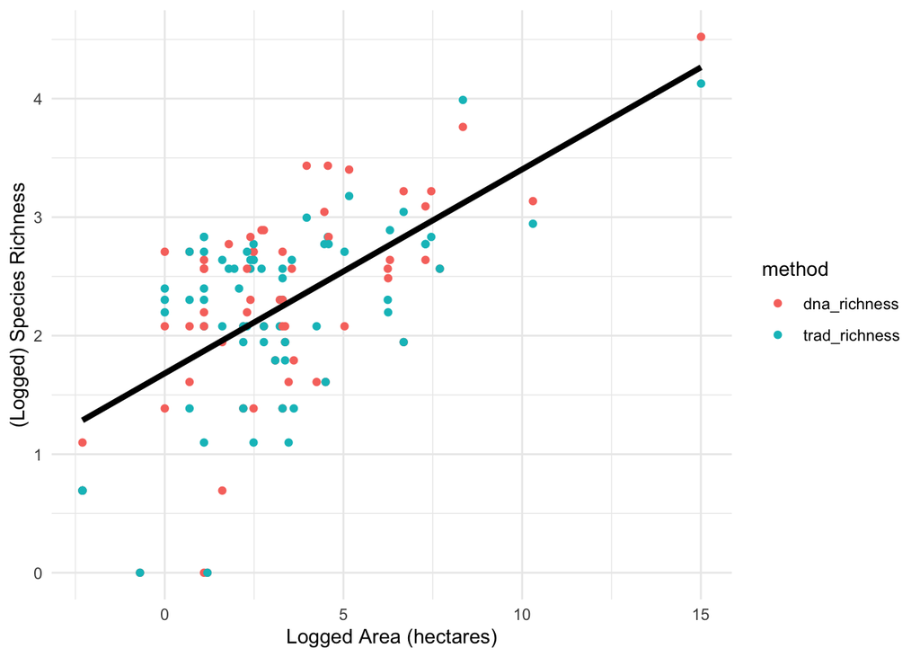

Figure 2. Model 0: Species richness (logged) regressed on logged area in hectares.Peach is eDNA metabarcoding. Teal is traditional methods.

```r
m_0 <- lm(species_richness_log ~ area_ha_log, data = sar_long)

fig_m_0 <- ggplot(sar_long, aes(x = area_ha_log, y = species_richness_log, color = method)) +
  geom_point() +
  geom_smooth(method="lm", formula = y ~ x, size=1.5, color="black", se=FALSE) +
  labs(x = "Logged Area (hectares)", y = "(Logged) Species Richness") +
  theme_minimal()

fig_m_0
```

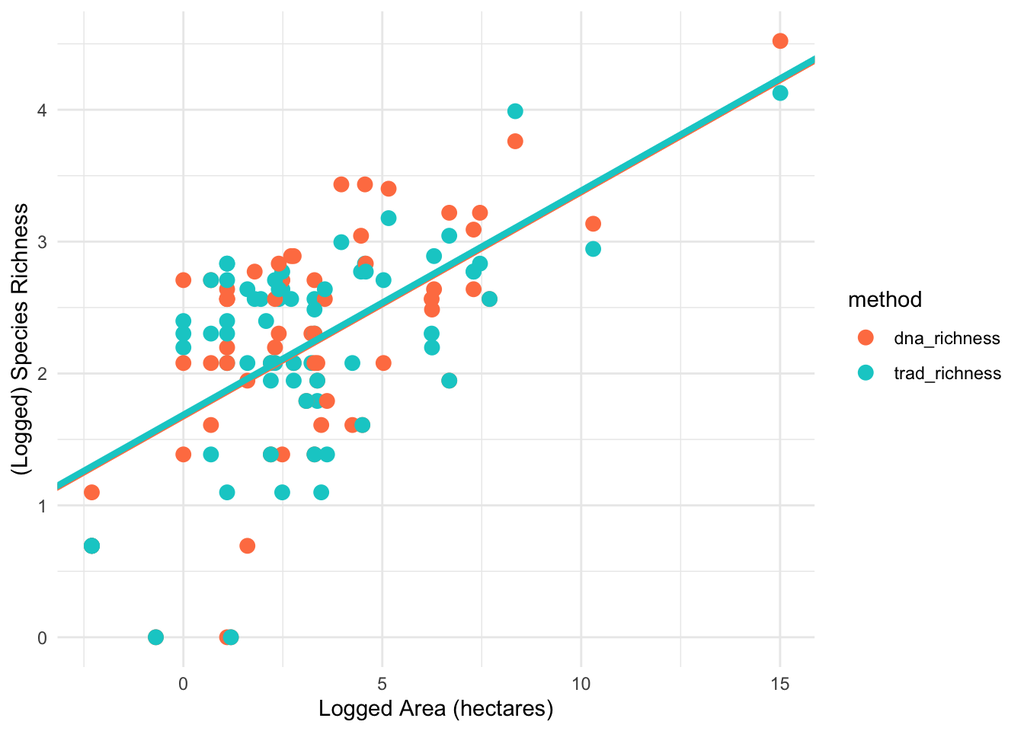

Figure 3. Model 2: Species richness (logged) regressed on logged area in hectares plus method used.

```r
fig_m_2 <- ggplot(sar_long, aes(x = area_ha_log, y = species_richness_log, color = method)) +
  geom_point(size = 3) +
  scale_color_manual(values=c("coral", "cyan3")) +
  geom_abline(intercept= 1.67657, slope=0.17, size=1.5, color="coral") +
  geom_abline(intercept= (1.67657+0.01), slope=0.17, size=1.5, color="cyan3")  +
  labs(x = "Logged Area (hectares)", y = "(Logged) Species Richness") +
  theme_minimal()

fig_m_2
```

Note that both methods have the same slope (0.17) response logged area (hectares). The only minor aspect that drives a difference in methods is a slight change in the intercept.The reference method, eDNA metabarcoding, has an intercept of 1.67657, and the traditional methods has an intercept of 1.68714.

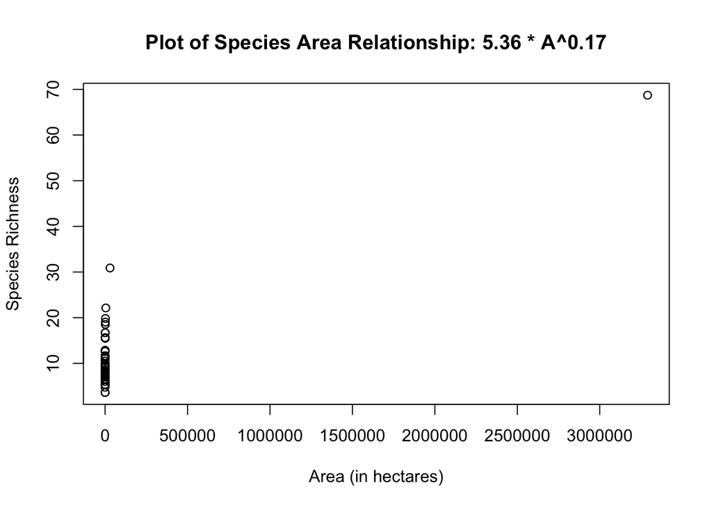

Figure 4. Predictions for species richness based on the area observations in this dataset, using the species area relationship equation, determined by Model 0.

```r
A = sar_long$area_ha
y = 5.36*A^(0.17)
plot(A,y,
     main = "Plot of Species Area Relationship: 5.36 * A^0.17",
       xlab = "Area (in hectares)",
       ylab = "Species Richness")
```

To specifically answer our research question: “Does Environmental DNA metabarcoding estimate the species area relationship (SAR) the same or different than traditional fishing gear?” We can confidently state that no, the statistics show that whether eDNA metabarcoding or traditional methods are used, there is no significant impact on improving the specificity of our ability to determine the species richness in that area.

### Checking assumptions for Model 0:

#### Linearity

There is a linear relationship between the log area (in hectares) of study location and the species richness value.

#### Independence:

From the information available, it can be concluded that the observations were independently collected, do not connect to each other, and are not part of a time series. A possible factor at play could be climate change, which affected everywhere in the world, but differently. However, we will disregard that for now.

## DISCUSSION

In the paper by McElroy et al., (2020), they state that “the peak difference in performance for eDNA metabarcoding compared to conventional surveys occurred at a species richness of 30.” This was for freshwater sites, however for marine sites, there were not enough data to perform the relative performance parity. This is noteworthy, because of the 132 observations we have in the dataset for this work, only a handful (5 observations) contain >30 species. Yet still, we conducted a statistical comparison between the each method, eDNA metabarcoding and traditional methods, and determined that there is no statistical difference between their performances of reporting species richness. In time, with deeper understanding of eDNA metabarcoding, such as more accurate calibration systems, and greater quantification of degradation of DNA and transport of DNA in various environments, eDNA will surpass traditional methods and become the standard method of determining species richness in both freshwater and marine environments for the benefit of ecological study and natural resource management.

## REFERENCES

Barbour, C. D., & Brown, J. H. (1974). Fish Species Diversity in Lakes. The American Naturalist, 108(962), 473–489. https://doi.org/10.1086/282927

Jerde, C. L. (2021). Can we manage fisheries with the inherent uncertainty from eDNA? Journal of Fish Biology, 98(2), 341–353. https://doi.org/10.1111/jfb.14218

McElroy, M. E., Dressler, T. L., Titcomb, G. C., Wilson, E. A., Deiner, K., Dudley, T. L., Eliason, E. J., Evans, N. T., Gaines, S. D., Lafferty, K. D., Lamberti, G. A., Li, Y., Lodge, D. M., Love, M. S., Mahon, A. R., Pfrender, M. E., Renshaw, M. A., Selkoe, K. A., & Jerde, C. L. (2020). Calibrating Environmental DNA Metabarcoding to Conventional Surveys for Measuring Fish Species Richness. Frontiers in Ecology and Evolution, 8, 276. https://doi.org/10.3389 /fevo.2020.00276